### Graphical representation of individuals and variable categories

To further clarify the MCA results graphical representation is used. Firstly, a biplot showing the global pattern within the data is created. Observations are represented by blue points and variables by red triangles and labels. The distance between any observation points or variable points gives a measure of their similarity (or dissimilarity). Similar types of individuals are close on the map, as well as similar kinds of variables.

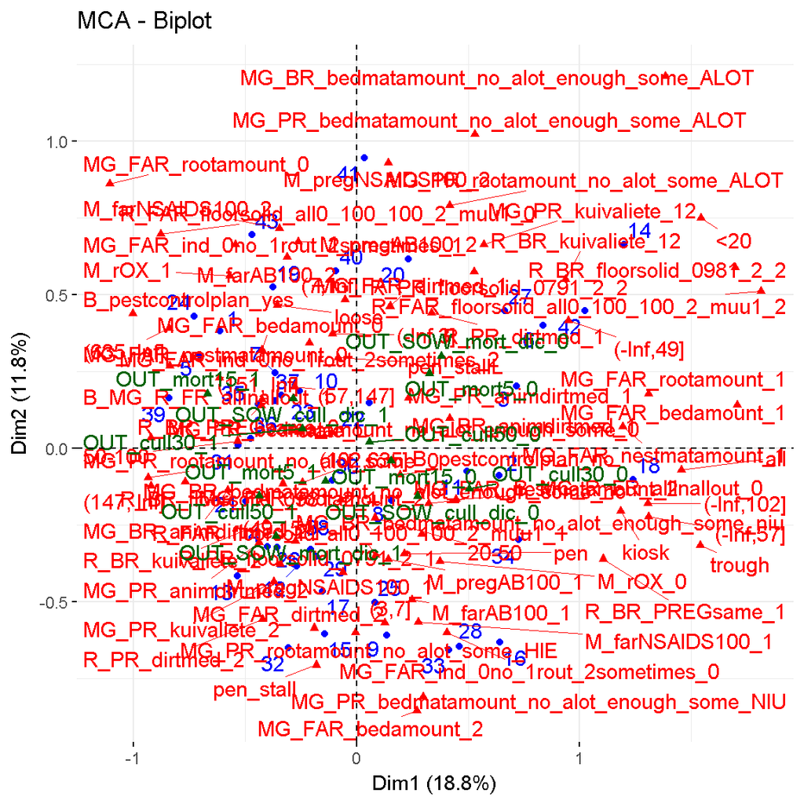

```r
fviz_mca_biplot(res_mca,
               repel = TRUE, # Avoid text overlapping (slow if many point)
               ggtheme = theme_minimal())
```